# Assignment_9_script

Rosemarie Kent

2024-03-26

I am renaming the data set to grad

```r
grad <- read.csv('./GradSchool_Admissions.csv')
```

I will now create multiple logistic regression models based on the variables, GRE score, GPA, and School Rank.

```r
library(tidyverse)
library(ggplot2)
library(performance)
library(easystats)
grad <- read.csv('./GradSchool_Admissions.csv')
model1 <- grad %>%
  glm(formula=as.logical(admit)~gre*gpa+rank, family='binomial')

model1_rmse <- performance(model1)$RMSE


model2 <- grad %>%
  glm(formula=as.logical(admit)~gre*gpa*rank, family='binomial')

model2_rmse <- performance(model2)$RMSE

model3 <- grad %>%
  glm(formula=as.logical(admit)~gre+gpa*rank, family='binomial')

model3_rmse <- performance(model3)$RMSE

model4 <- grad %>%
  glm(formula=as.logical(admit)~gre*rank+gpa, family='binomial')

model4_rmse <- performance(model4)$RMSE

model5 <- grad %>%
  glm(formula=as.logical(admit)~gre+rank+gpa, family='binomial')

model5_rmse <- performance(model5)$RMSE

model6 <- grad %>%
  glm(formula=as.logical(admit)~(gre+gpa)*rank, family='binomial')

model6_rmse <- performance(model5)$RMSE
```

For each of the models I will also calculate the RSME

```r
rmse_table <- data.frame(
  Model = c("Model 1", "Model 2", "Model 3", "Model 4","Model 5","Model 6"),
  RMSE = c(model1_rmse, model2_rmse, model3_rmse, model4_rmse,model5_rmse,model6_rmse)
)

print(rmse_table)
```

```
##     Model      RMSE
## 1 Model 1 0.4399238
## 2 Model 2 0.4396607
## 3 Model 3 0.4416400
## 4 Model 4 0.4418033
## 5 Model 5 0.4417990
## 6 Model 6 0.4417990
```

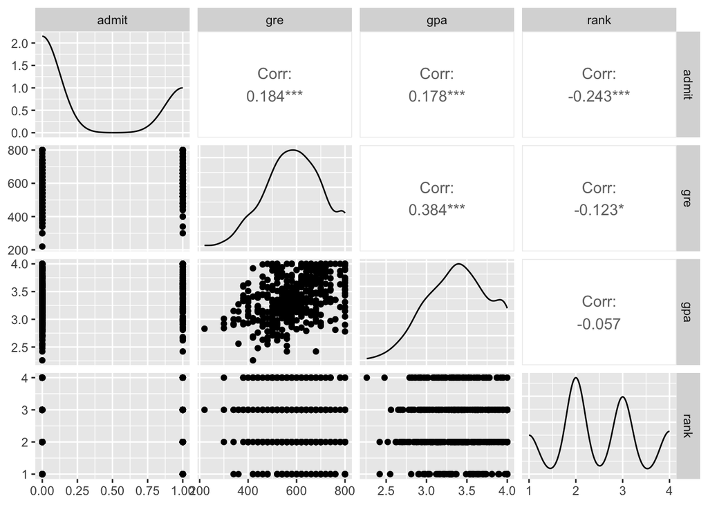

```r
library(GGally)
grad %>% ggpairs()
```

I have created a plot that will compare all the models to find which one is the best fit. I also am looking at a table to compare the different model’s.

```r
compare_performance(model1,model2,model3,model4,model5,model6)
```

```
## # Comparison of Model Performance Indices
##
## Name   | Model | AIC (weights) | AICc (weights) | BIC (weights) | Tjur's R2 |  RMSE | Sigma | Log_loss | Score_log | Score_spherical |   PCP
## --------------------------------------------------------------------------------------------------------------------------------------------
## model1 |   glm | 466.6 (0.434) |  466.7 (0.432) | 486.6 (0.158) |     0.105 | 0.440 | 1.000 |    0.571 |   -50.481 |           0.004 | 0.612
## model2 |   glm | 472.2 (0.026) |  472.6 (0.023) | 504.2 (<.001) |     0.106 | 0.440 | 1.000 |    0.570 |   -50.593 |           0.005 | 0.613
## model3 |   glm | 469.3 (0.110) |  469.5 (0.110) | 489.3 (0.040) |     0.100 | 0.442 | 1.000 |    0.574 |   -50.609 |           0.004 | 0.610
## model4 |   glm | 469.4 (0.105) |  469.6 (0.104) | 489.4 (0.038) |     0.099 | 0.442 | 1.000 |    0.574 |   -50.491 |           0.004 | 0.609
## model5 |   glm | 467.4 (0.284) |  467.5 (0.291) | 483.4 (0.762) |     0.099 | 0.442 | 1.000 |    0.574 |   -50.496 |           0.004 | 0.609
## model6 |   glm | 471.3 (0.041) |  471.5 (0.040) | 495.3 (0.002) |     0.100 | 0.442 | 1.000 |    0.574 |   -50.582 |           0.005 | 0.610
```

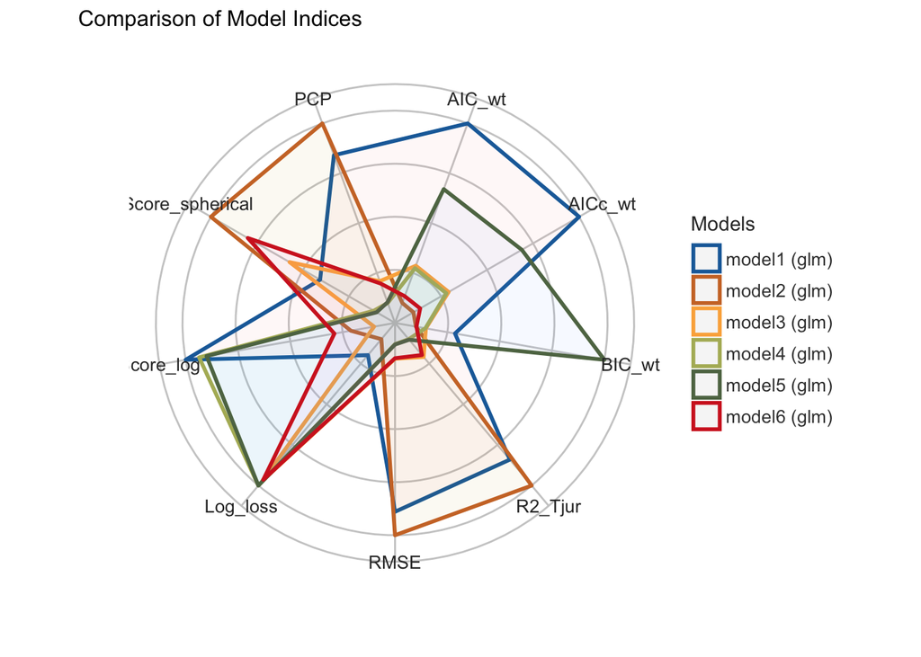

```r
compare_performance(model1,model2,model3,model4,model5,model6) %>% plot()
```

Looking at the table, model 1 and model 2 have the lowest RSME’s but model one does have the lowest AICC.Based on the plot I am going to use Model 1, as it is the best fit for many of the variables of interest such as AICC, AIC, and almost RSME.

Using model I I will predict values for admittance a nd non admittance.

```r
grad$pred <- predict(model1,grad,type='response')
```

Using the prediction from model One I am going to plot boxplots and line plots that will show the probability of getting admitted into graduate school based on gpa and I will color it by school rank.

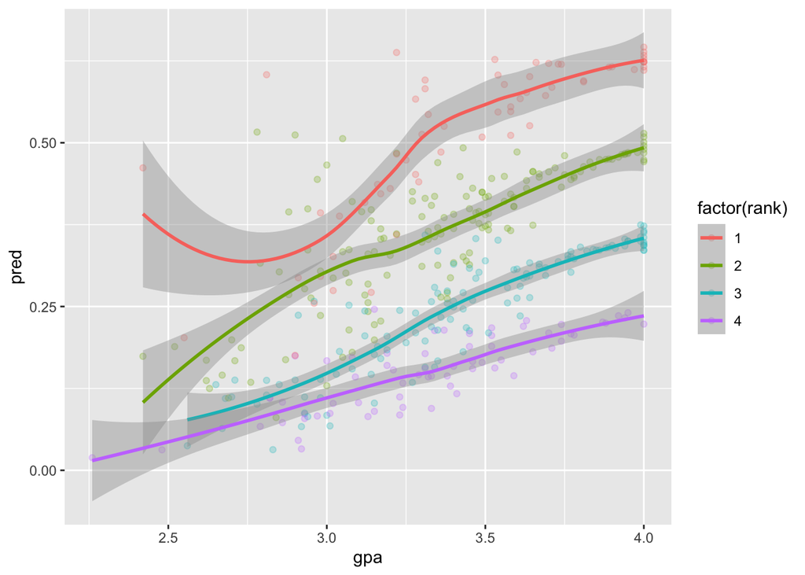

```r
grad %>%
  ggplot(aes(x=gpa,y=pred,color=factor(rank)))+
  geom_point(alpha=.25)+
  geom_smooth()
```

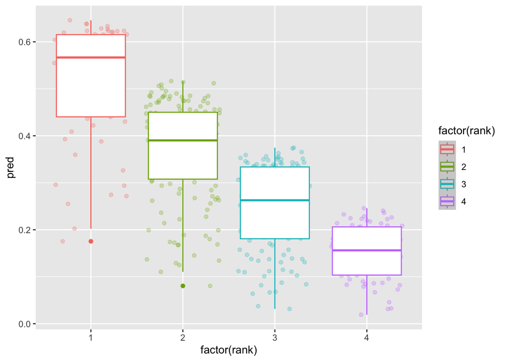

```r
grad %>%
  ggplot(aes(x=factor(rank),y=pred,color=factor(rank)))+
  geom_jitter(alpha=.25)+
  geom_boxplot()+
  geom_smooth()
```

Based on the graphs and our plots it it looks like Rank plays a large impact of graduate school acceptance. If you are at a rank one school your probability of getting in is much larger then someone attending a rank 4 school.